# aoristic compare

### Repeat with no `dplyr`

The same code chunks as above mashed into one chunk with a the only change being the commenting out of `dplyr` code from `my_aorist2()` function. While this shows the speed increase that is achieved by `foverlaps()`, it is not a fair comparison as the removal of `mutate()` will still need to be replaced by some data munging. Or, just deal with the half-second of execution time and move along :)

```r
my_aorist2 <- function(data, weight = 1, start.date = 0, end.date = 2000,
                      bin.width = 100, round_int = 4) {
  require(dplyr)
  require(data.table)
  time_steps <- data.frame(
    step  = seq(1:(abs(end.date)/bin.width)), # end not start b/c pos dates
    Start = seq(start.date,(end.date-bin.width), by = bin.width),
    End   = seq((start.date+bin.width),end.date, by = bin.width))
  setDT(time_steps)
  setDT(data)
  setkey(time_steps, Start, End)
  overlap_names <- data.table::foverlaps(data, time_steps,
                                         type = "any", which = FALSE) %>%
    filter(i.Start != End & i.End != Start)
  aorist <- overlap_names # %>%
#     data.frame() %>%
#     group_by(name) %>%
#     mutate(site_count = n(),
#            W = (bin.width / (i.End - i.Start)), # SWITCHED b/c of pos dates
#            W = round(W,round_int)) %>%
#     arrange(name, step) %>%
#     group_by(step) %>%
#     summarise(step_W = sum(W),
#               median_step_W = median(W),
#               site_count = n()) %>%
#     right_join(., time_steps, by = "step") %>%
#     replace_na(list(step_W = 0, site_count = 0, median_step_W = 0)) %>%
#     mutate(bin.no = step,
#            bin = paste0(Start, "-", End),
#            aorist = step_W) %>%
#     dplyr::select(bin, bin.no, aorist)
  return(aorist)
}

execute_time_results <- matrix(nrow = length(sim_site_count_seq), ncol = 3)
colnames(execute_time_results) <- c("site_count", "aorist", "my_aorist")
# pb <- txtProgressBar(min = 0, max = length(sim_site_count_seq), style = 3, char="*")
for(i in seq_along(sim_site_count_seq)){
  sim_site_count <- sim_site_count_seq[i]
  sites2 <- data.frame(
    name  = seq(1:sim_site_count),
    begin = sample(seq(-5000,-1000, by = 100), sim_site_count, replace = TRUE)) %>%
    mutate(end = begin + sample(seq(100, 3000, by = 100),
                                length(begin), replace = TRUE),
           end = ifelse(end > 0, 0, end)) %>%
    dplyr::select(begin, end, name) %>%
    mutate(begin = abs(begin), end = abs(end)) %>%
    dplyr::rename(Start = end, End = begin)

  aor.start.time <- Sys.time()
    aor <- archSeries_aorist(sites2, end.date = 5000, bin.width = 100)
  aor.end.time <- Sys.time()
  my.aor.start.time <- Sys.time()
    my_aor <- my_aorist2(sites2, end.date = 5000, bin.width = 100) # my_aorist2()
  my.aor.end.time <- Sys.time()

  aor.execute.time <- aor.end.time - aor.start.time
  my.aor.execute.time <- my.aor.end.time - my.aor.start.time
  execute_time_results[i,1] <- sim_site_count
  execute_time_results[i,2] <- aor.execute.time
  execute_time_results[i,3] <- my.aor.execute.time
  # setTxtProgressBar(pb, i)
}
# close(pb)

execute_time_results <- data.frame(execute_time_results) %>%
  mutate(diff = my_aorist - aorist)

execute_time_summary <- execute_time_results %>%
  summarise(site_count_min = floor(min(site_count)),
            site_count_max = floor(max(site_count)),
            mean_aorist    = round(mean(aorist),3),
            mean_my_aorist = round(mean(my_aorist),3),
            max_diff       = round(min(diff),3), # reverse b/c negative time
            min_diff       = round(max(diff),4), # reverse b/c negative time
            mean_diff      = round(mean(diff),3)) %>%
  t()
print(execute_time_summary)
```

```
##                      [,1]
## site_count_min    10.0000
## site_count_max 10000.0000
## mean_aorist        0.2490
## mean_my_aorist     0.0250
## max_diff          -0.3960
## min_diff          -0.1475
## mean_diff         -0.2230
```

```r
aor_lm <- lm(aorist ~ site_count, data = execute_time_results)
aor_lm <- (as.numeric(coef(aor_lm))[2]) * 10000
my_aor_lm <- lm(my_aorist ~ site_count, data = execute_time_results)
my_aor_lm <- (as.numeric(coef(my_aor_lm))[2]) * 10000
message(paste0("Initially, my_aoristic is ", round(execute_time_results[2,"diff"],3),
  " seconds faster at ", execute_time_results[2,"site_count"], " sites, is equivalent at 5000 sites, and is ",
  round(execute_time_results[201,"diff"],3), " seconds slower at 10,000 sites. For every 1000 sites added: aoristic = ", round(aor_lm,4), " seconds increase; my_aoristic = ",
               round(my_aor_lm,4), " seconds increase in execution time."))
```

[output not shown]

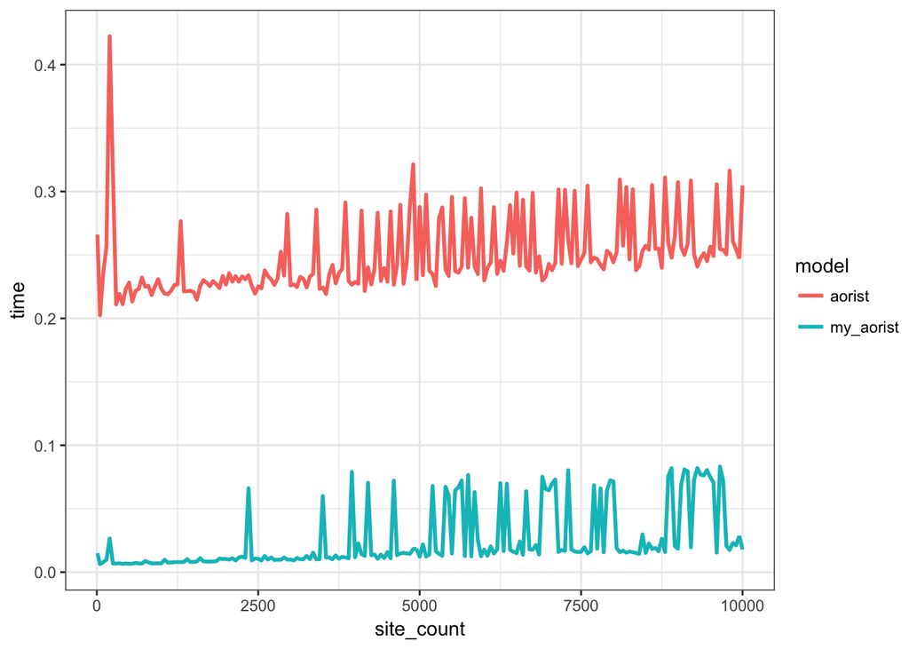

```r
plot_dat <- execute_time_results %>%
  dplyr::select(site_count, aorist, my_aorist) %>%
  gather(model, time, -site_count)

ggplot(plot_dat, aes(x = site_count, y = time, group = model, color = model)) +
  geom_line(size = 1) +
  theme_bw()
```